# 美國西南部樹輪生長與環境因子之排序分析 Dendrochronology Ordination Analysis: Environmental Drivers of Pinus ponderosa in Southwestern USA

Data analysis in R (Cluster analysis/ PCA/ DCA/ RDA)

## 資料

- 資料來源:https://www.ncdc.noaa.gov/data-access/paleoclimatology-data
- 物種:*Pinus ponderosa* Douglas (western yellow pine)
- 介紹:收集的樹輪資料均位於美國地區且為同一物種，但為四個不同作者(Brubaker, Dean, Graulich and Graybil)提供，樣木的位置也有落差
- 資料為每一年[樹輪輪寬寬度](https://github.com/a10293499/TreeRing-and-environmental-variables/blob/main/chronology%20data.csv)(chronology data)及[每一樣木分布位置及海拔](https://github.com/a10293499/TreeRing-and-environmental-variables/blob/main/chronology%20env%20data.csv)(chronology env data)

## 目標

- 由於樹木生長受環境很大影響，通常溫度較溫暖雨量較多，可生長較快造成輪寬較寬；反之，輪寬則會較窄。Danek et.al (2017) 藉由排序分析發現Carpathian山脈的樹木年輪樹輪與經度和海之間有相關性，樹輪會隨著經度和海拔的變動而變化。 因此，我想知道在其他地區是否仍然有這樣的關係。此外，他們在分析中沒有添加環境變量，在本研究中也會加入環境因子進行分析。

## 方法說明

- Classification

  > 以hierarchical agglomerative clustering (Ward’s method)進行分析，k值設定為4，因為資料來自大致來自於4個不同的地方(部分重疊)，能否單純藉由輪寬將四個來源區分開來。
- Detrended Correspondence Analysis(DCA) and Principle Component Analysis(PCA)
  > - 用DCA決定是linear 或 unimoda，假如第一象限的DCA小於3D則使用linear。
  > - PCA用來將3D降維成2D。
- Redundancy Analysis (RDA)

  > 加入環境因子，以RDA進行分析。

## 資料處理

排除生長年份過短（小於 100 年）的樣本，並篩選重疊年份區間以確保分析的一致性。

Data summary

| Name | env |
| --- | --- |
| Number of rows | 72 |
| Number of columns | 5 |
| _______________________ |  |
| Column type frequency: |  |
| character | 1 |
| numeric | 4 |
| ________________________ |  |
| Group variables | None |

**Variable type: character**

| skim_variable | n_missing | complete_rate | min | max | empty | n_unique | whitespace |
| --- | --- | --- | --- | --- | --- | --- | --- |
| author | 0 | 1 | 4 | 8 | 0 | 4 | 0 |

**Variable type: numeric**

| skim_variable | n_missing | complete_rate | mean | sd | p0 | p25 | p50 | p75 | p100 | hist |
| --- | --- | --- | --- | --- | --- | --- | --- | --- | --- | --- |
| region_classification | 0 | 1 | 2.75 | 1.22 | 1.00 | 2.0 | 3.00 | 4.00 | 4.00 | ▃▅▁▂▇ |
| Latitude | 0 | 1 | 38.71 | 5.43 | 31.70 | 34.3 | 36.41 | 41.69 | 48.57 | ▇▆▅▁▆ |
| Longitude | 0 | 1 | -112.16 | 5.42 | -122.08 | -117.3 | -110.67 | -108.26 | -104.87 | ▅▂▁▇▅ |
| Elevation | 0 | 1 | 1892.33 | 502.38 | 765.00 | 1665.0 | 2013.00 | 2225.00 | 2663.00 | ▂▃▅▇▅ |

## 樣木分布

- 樣木分布位置如下圖所示
- **Red(1)**: Brubaker; **Blue(2)**: Graulich; **Green(3)**: Dean; **Purple(4**): Graybil)

```r
# 1. 定義顏色：根據 region_classification (env[, 2]) 自動生成色板
# 假設 region_classification 是類別型變數
color_pal <- colorFactor(palette = "Set1", domain = env$region_classification)

# 2. 建立互動式地圖
leaflet(env) %>%
  addTiles() %>%  # 使用預設的 OpenStreetMap 底圖
  addCircleMarkers(
    lng = ~Longitude,
    lat = ~Latitude,
    color = ~color_pal(region_classification), # 外框顏色
    fillColor = ~color_pal(region_classification), # 填充顏色
    fillOpacity = 0.7,
    radius = 8,
    stroke = TRUE,
    weight = 1,
    # 滑鼠點擊時顯示的內容：樣區名稱與分類
    popup = ~paste0("樣區: ", rownames(env), "<br>",
                    "區域分類: ", region_classification, "<br>",
                    "海拔: ", Elevation, " m")
  ) %>%
  # 加入圖例
  addLegend(
    pal = color_pal,
    values = ~region_classification,
    title = "區域分類",
    position = "bottomright"
  )
```

[interactive chart not shown]

## 群聚分析 (Hierarchical Clustering)

使用歐基里德距離（Euclidean Distance）與 Ward’s Method 進行分群，由於想確認單就樹輪寬度資料能否區分4個來源，因此在設定上將樣區歸類為 4 個主要群聚(C1~C4)。

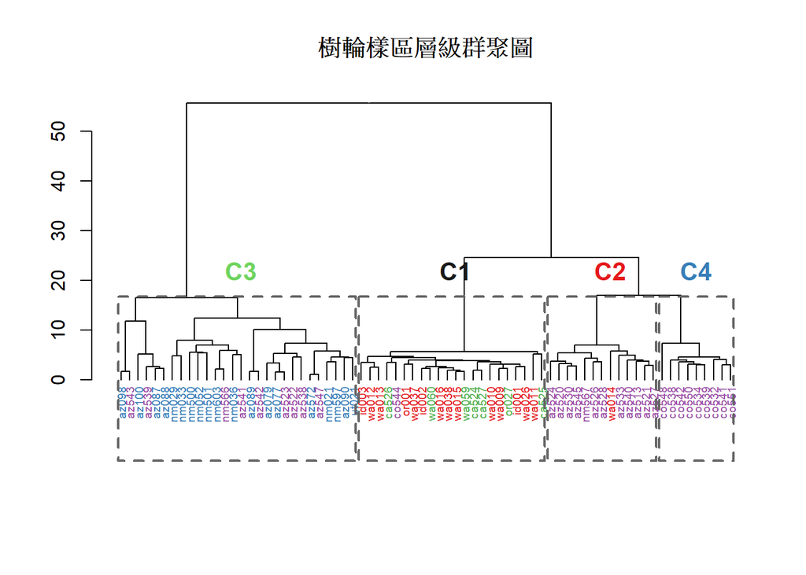

```r
# 1. 建立樹狀圖
dend <- as.dendrogram(hclust(d = dist(all.cutr, method = "euclidean"), method = 'ward.D'))

# 2. 設定下方文字顏色 (原本地理來源的分群)
dend <- set(dend, "labels_cex", 0.6)
# map_colors 對應 region_classification 的紅藍綠紫
map_colors <- c("#E41A1C", "#377EB8", "#4DAF4A", "#984EA3")
#map_colors <- c(unique(env[,2]))
region_idx <- as.numeric(as.factor(cls))
labels_colors(dend) <- map_colors[region_idx][order.dendrogram(dend)]

# 3. 繪製圖表
par(mar = c(8, 4, 4, 2))
plot(dend, main = "樹輪樣區層級群聚圖")

# 4. 畫出分群框框：改為深灰色 (gray40)，避免與下方紅藍綠紫混淆
rect.dendrogram(dend, k = 4, border = 'gray40', lty = 2, lwd = 2)

# 5. 在框框上方標註 C1~C4：統一使用深灰色，並精確調整位置
# 根據妳目前的圖：左到右分別是 C3, C1, C2, C4
# 微調後的 x 座標：
text(x = c(15, 40, 58, 68),
     y = 22,
     labels = c("C3", "C1", "C2", "C4"),
     cex = 1.3,
     font = 2,
     col = c('#6FD45E','gray10','#E41A1C','#377EB8'))
```

**Note**

- 從層級群聚圖可看出大致分成四個分群(C1~C4)，同個來源大多會被分到同一群內。
- 值得注意的是C3與C4兩個分群在群聚分析中是最遠的，但這兩群分別為 **Blue(2)**: Graulich 跟 **Purple(4**): Graybil)，在樣區位置上反而是比較近的，推測這兩區的樣本受其他環境因子影響(非經緯度)的可能性較大。

## 排序法分析 (Ordination)

```r
clust.allr <- hclust(d = dist(all.cutr, method = "euclidean"), method = 'ward.D')
clust.allcutr <- cutree(clust.allr, k = 4)

# 1. 執行 DCA
dca_result <- decorana(all.cutr)

# 2. 查看 DCA 結果
dca_result
```

```
Call:
decorana(veg = all.cutr)

Detrended correspondence analysis with 26 segments.
Rescaling of axes with 4 iterations.
Total inertia (scaled Chi-square): 0.107

                        DCA1     DCA2     DCA3     DCA4
Eigenvalues          0.03511 0.009546 0.007218 0.004073
Additive Eigenvalues 0.03511 0.009549 0.007243 0.004160
Decorana values      0.03618 0.008032 0.004232 0.002430
Axis lengths         0.69856 0.461782 0.441246 0.313124
```

```r
#ordiplot(dca_result,type ='n', display = 'sites') #smaller than 3 S.D--linear
#points (dca_result, display = 'sites',col = cls)
```

**Note**DCA 分析**

經由去趨勢對應分析 (DCA) 檢測，第一軸梯度長度 (Axis length) 為 0.698，遠小於 3 S.D. 的閾值。這證實了樣區間的樹輪特徵呈現線性反應，因此採用主成分分析 (PCA) 作為後續排序分析之模型。

```r
# 確保 pca 已經建立
pca <- rda(X = all.cutr)

summ_pca <- summary(pca)
summ_pca$cont$importance[, 1:5]
```

```
                            PC1        PC2        PC3        PC4        PC5
Eigenvalue            5.4691395 1.58646158 1.28166405 0.93863833 0.72497781
Proportion Explained  0.3267091 0.09477019 0.07656255 0.05607128 0.04330788
Cumulative Proportion 0.3267091 0.42147926 0.49804181 0.55411309 0.59742097
```

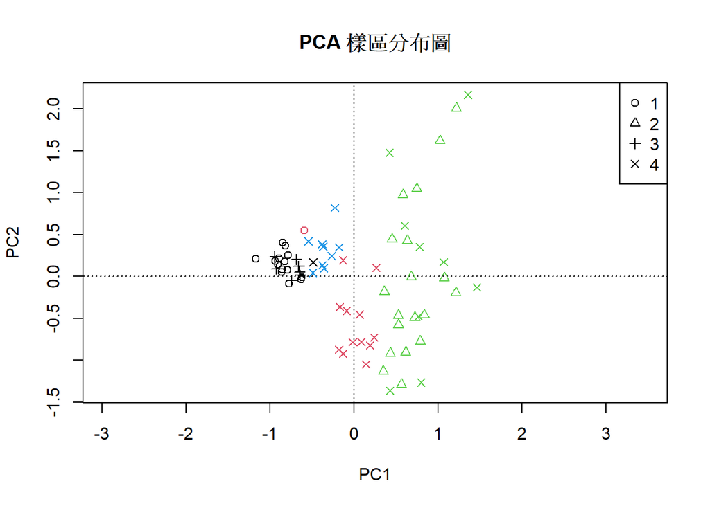

```r
# 繪圖
ordiplot(pca, type = 'n', xlim = c(-1.5, 2), main = "PCA 樣區分布圖")
points(pca, pch = cls, col = clust.allcutr)
legend("topright", legend = c('1','2','3','4'), pch = 1:4)
```

**Note**PCA 分析**

- PC1 (32.7%)：第一主成分解釋了資料中約三分之一的變異，通常代表最強大的環境梯度。 PC2 (9.5%)：第二主成分的解釋力較弱，代表次要的環境因子。
- 前兩軸累計 (42.1%)：兩軸可以呈現原始資料中 42.1% 的特徵資訊。
- 相同符號表示樣本為同個來源；相同顏色表示經過群聚分析後歸類為同一群(C1~C4)，歸類到同群的，在PC1上較為接近。
- 從上圖中一樣可看出相同來源會較靠近，搭配地理位置圖可發現，當樣木位置由北往南(1○↛ 3+ ↛ 4 X ↛ 2 三角 ↛ 4 X )移動，PC1值增加；樣木位置由西往東移動( 3+ ↛ 4 X ↛ 2 三角 ↛ 4 X )，PC1值也增加。搭配解釋率，表示PC1可能受樣本經緯度影響大。
- X 4在PC2軸中有極大的變化。

**環境因子擬合 (Environmental Fitting)**

將經度、緯度與海拔擬合至 PCA 結果中，並執行 Bonferroni 校正確保顯著性。

```r
ef <- envfit(pca ~ Latitude + Longitude + Elevation, data = env, perm = 999)

# P-value 校正
ef.adj <- ef
pvals.adj <- p.adjust(ef$vectors$pvals, method = 'bonferroni')
ef.adj$vectors$pvals <- pvals.adj

#解釋率r2
ef.adj$vectors$r
```

```
 Latitude Longitude Elevation
0.6860294 0.3624035 0.4173295
```

```r
print(ef.adj)
```

```
***VECTORS

               PC1      PC2     r2 Pr(>r)
Latitude  -0.94075  0.33911 0.6860  0.003 **
Longitude  0.94738 -0.32010 0.3624  0.003 **
Elevation  0.95964 -0.28122 0.4173  0.003 **
---
Signif. codes:  0 '***' 0.001 '**' 0.01 '*' 0.05 '.' 0.1 ' ' 1
Permutation: free
Number of permutations: 999
```

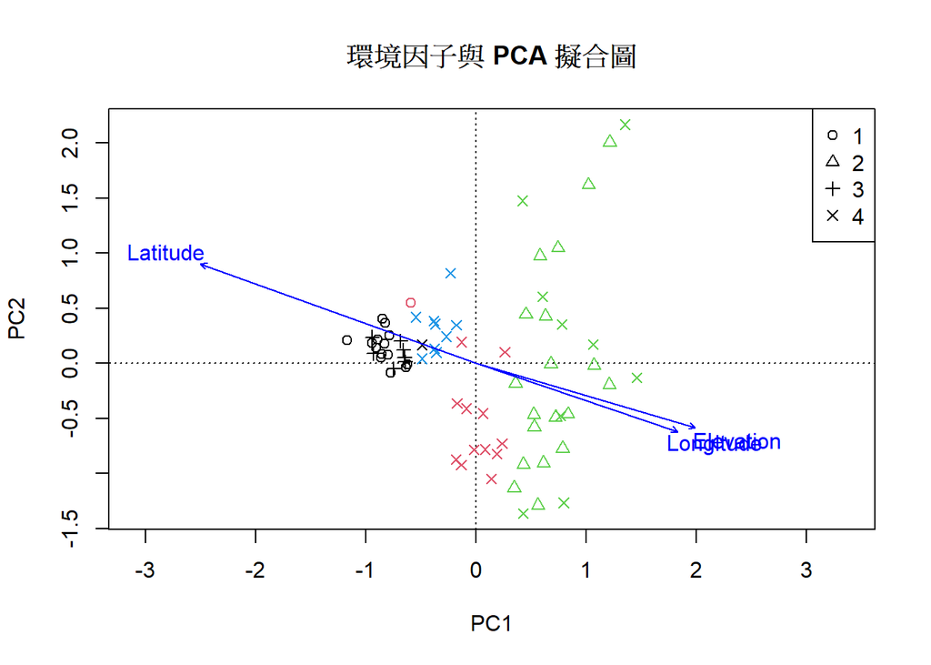

```r
plot(pca, type = "n", main = "環境因子與 PCA 擬合圖")
points(pca, pch = cls, col = clust.allcutr)
legend("topright", legend = c('1','2','3','4'), pch = 1:4)
plot(ef.adj)
```

**Tip解釋率**

本研究中

緯度的解釋率 $r^2$ 為 0.686

經度的解釋率$r^2$為 0.362

海拔的解釋率 $r^2$ 為 0.417

三個因子的解釋率為個別計算，因子間會有共線性，表示它們共享了一部分對樹輪的解釋力。

**Note**

- 從解釋率$r^2$來看，緯度對本次樹輪資料集解釋率最大，其次為海拔，經度的影響最小。
- 從上表與上圖中都顯示這三個環境因子與橫軸PC1(解釋率32.7%)有強烈相關性：緯度與PC1為負相關；經度與海拔則和PC1呈現正相關。而這三個因子雖然也會影響PC2的佔比不高(大約30%上下)，因此這個資料在PC2上的變易更可能來於非地理性因素，然而此部分需更進一步有相關資料去分析研究。
- 圖中的樣木和這三個地理因子的解讀上，**愈往左的樣區，緯度越高(1跟3)；愈往右的樣區，經度(西半球負值)和海拔越高(2跟4)。**

## 冗餘分析 (Redundancy analysis, RDA)

環境因子擬合分析主要是在看環境與現有資料的相關性，是在PCA區分好後才塞入環境因子。然而，RDA是在計算時就規定好座標軸，因此能看出**「如果只考慮這些環境因子(緯度/經度/海拔)，樹輪的生長特徵能被解釋到什麼程度？」**

```r
# 1. 執行 RDA
rda_model <- rda(all.cutr ~ Latitude + Longitude + Elevation, data = env)
summ_rda <- summary(rda_model)
summ_rda$cont$importance[, 1:3]
```

```
                           RDA1       RDA2        RDA3
Eigenvalue            3.6363411 0.69965243 0.154684818
Proportion Explained  0.2172235 0.04179502 0.009240381
Cumulative Proportion 0.2172235 0.25901852 0.268258900
```

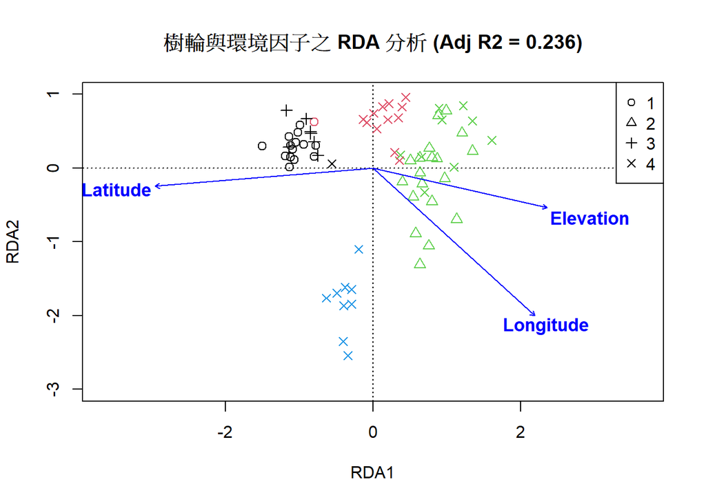

```r
# 2. 提取解釋率
rda_stat <- RsquareAdj(rda_model)
adj_r2 <- rda_stat$adj.r.squared

# 3. 繪圖初始化
plot(rda_model, type = "n",
     main = paste0("樹輪與環境因子之 RDA 分析 (Adj R2 = ", round(adj_r2, 3), ")"),
     xlim = c(-3, 3), ylim = c(-3, 1))

# 4. 點位
points(rda_model, display = "sites",
       pch = cls,
       col =clust.allcutr,
       cex = 1.1)

# 5. 環境因子
text(rda_model, display = "bp", col = "blue", cex = 1.1, font = 2)

# 6. 圖例
legend("topright",
       legend = c('1', '2', '3', '4'),
       pch = 1:4)
```

**Note**